# Fake News Detection Using Machine Learning

This notebook aims to build a binary classifier that detects whether a political statement is real or fake using a labeled dataset from the LIAR benchmark. The project walks through data preprocessing, feature engineering, model training, evaluation, and interpretability.

```python
import pandas as pd

train_df = pd.read_csv('D:/Datasets1/liar_dataset/train.tsv', sep='\t', header=None)
test_df = pd.read_csv('D:/Datasets1/liar_dataset/test.tsv', sep='\t', header=None)
val_df = pd.read_csv('D:/Datasets1/liar_dataset/valid.tsv', sep='\t', header=None)

train_df.head()
```

|  | 0 | 1 | 2 | 3 | 4 | 5 | 6 | 7 | 8 | 9 | 10 | 11 | 12 | 13 |
| --- | --- | --- | --- | --- | --- | --- | --- | --- | --- | --- | --- | --- | --- | --- |
| 0 | 2635.json | false | Says the Annies List political group supports ... | abortion | dwayne-bohac | State representative | Texas | republican | 0.0 | 1.0 | 0.0 | 0.0 | 0.0 | a mailer |
| 1 | 10540.json | half-true | When did the decline of coal start? It started... | energy,history,job-accomplishments | scott-surovell | State delegate | Virginia | democrat | 0.0 | 0.0 | 1.0 | 1.0 | 0.0 | a floor speech. |
| 2 | 324.json | mostly-true | Hillary Clinton agrees with John McCain "by vo... | foreign-policy | barack-obama | President | Illinois | democrat | 70.0 | 71.0 | 160.0 | 163.0 | 9.0 | Denver |
| 3 | 1123.json | false | Health care reform legislation is likely to ma... | health-care | blog-posting | NaN | NaN | none | 7.0 | 19.0 | 3.0 | 5.0 | 44.0 | a news release |
| 4 | 9028.json | half-true | The economic turnaround started at the end of ... | economy,jobs | charlie-crist | NaN | Florida | democrat | 15.0 | 9.0 | 20.0 | 19.0 | 2.0 | an interview on CNN |

```python
# Assigning column names:
columns = ['id', 'label', 'statement', 'subject', 'speaker', 'job_title', 'state_info', 'party', 'barely_true_counts', 'false_counts',
           'half_true_counts', 'mostly_true_counts', 'pants_on_fire_counts', 'context']

train_df.columns = columns
test_df.columns = columns
val_df.columns = columns
```

## Data Exploration

The dataset includes statements, metadata (speaker, party, job title), and a truthfulness label. We explored missing values, label distribution, and key categorical variables. We also cleaned the text for modeling.

```python
# Simplifying labels:
fake_labels = ['false', 'pants-fire', 'barely-true']
real_labels = ['true', 'mostly-true', 'half-true']

def simplify_label(label):
    if label in fake_labels:
        return 'fake'
    elif label in real_labels:
        return 'real'
    else:
        return None

train_df['label_binary'] = train_df['label'].apply(simplify_label)
train_df = train_df.dropna(subset=['label_binary'])

test_df['label_binary'] = test_df['label'].apply(simplify_label)
test_df = test_df.dropna(subset=['label_binary'])

val_df['label_binary'] = val_df['label'].apply(simplify_label)
val_df = val_df.dropna(subset=['label_binary'])
```

```python
# Basic cleaning of Text

import re
import string

def clean_text(text):
    text = text.lower()
    text = re.sub(r'http\S+', '', text)  # remove URLs
    text = text.translate(str.maketrans('', '', string.punctuation))  # remove punctuation
    text = re.sub(r'\d+', '', text)  # remove numbers
    return text.strip()

train_df['clean_statement'] = train_df['statement'].astype(str).apply(clean_text)
```

```python
train_df.to_csv('D:/Datasets1/liar_dataset/train_cleaned.csv', index=False)
test_df.to_csv('D:/Datasets1/liar_dataset/test_cleaned.csv', index=False)
val_df.to_csv('D:/Datasets1/liar_dataset/val_cleaned.csv', index=False)
```

```python
train_df.isnull().sum()
```

```
id                         0
label                      0
statement                  0
subject                    2
speaker                    2
job_title               2898
state_info              2210
party                      2
barely_true_counts         2
false_counts               2
half_true_counts           2
mostly_true_counts         2
pants_on_fire_counts       2
context                  102
label_binary               0
clean_statement            0
dtype: int64
```

## Data Preprocessing

Missing values in categorical fields were filled with 'Unknown' to avoid data loss. We added binary flags to indicate original missing values. Statements were cleaned (lowercase, punctuation removal, etc.) and converted into TF-IDF features.

```python
# Fill the missing values with "Unknown" for Categorical Fields
train_df['job_title'] = train_df['job_title'].fillna('Unknown')
train_df['state_info'] = train_df['state_info'].fillna('Unknown')
train_df['subject'] = train_df['subject'].fillna('Unknown')
train_df['speaker'] = train_df['speaker'].fillna('Unknown')
train_df['party'] = train_df['party'].fillna('Unknown')
train_df['context'] = train_df['context'].fillna('Unknown')

# Fill count columns with 0
count_cols = ['barely_true_counts', 'false_counts', 'half_true_counts', 'mostly_true_counts', 'pants_on_fire_counts']
train_df[count_cols] = train_df[count_cols].fillna(0)

# Add Missing Value Flags “this value was missing originally.”
train_df['job_title_missing'] = train_df['job_title'] == 'Unknown'
train_df['state_info_missing'] = train_df['state_info'] == 'Unknown'

train_df.isnull().sum()
```

```
id                      0
label                   0
statement               0
subject                 0
speaker                 0
job_title               0
state_info              0
party                   0
barely_true_counts      0
false_counts            0
half_true_counts        0
mostly_true_counts      0
pants_on_fire_counts    0
context                 0
label_binary            0
clean_statement         0
job_title_missing       0
state_info_missing      0
dtype: int64
```

### EDA (Exploratory Data Analysis)

```python
# Basic Overview
print(train_df.shape)
print(train_df.dtypes)
print(train_df.head())
train_df.describe(include='all')
```

```
(10240, 18)
id                       object
label                    object
statement                object
subject                  object
speaker                  object
job_title                object
state_info               object
party                    object
barely_true_counts      float64
false_counts            float64
half_true_counts        float64
mostly_true_counts      float64
pants_on_fire_counts    float64
context                  object
label_binary             object
clean_statement          object
job_title_missing          bool
state_info_missing         bool
dtype: object
           id        label                                          statement  \
0   2635.json        false  Says the Annies List political group supports ...
1  10540.json    half-true  When did the decline of coal start? It started...
2    324.json  mostly-true  Hillary Clinton agrees with John McCain "by vo...
3   1123.json        false  Health care reform legislation is likely to ma...
4   9028.json    half-true  The economic turnaround started at the end of ...

                              subject         speaker             job_title  \
0                            abortion    dwayne-bohac  State representative
1  energy,history,job-accomplishments  scott-surovell        State delegate
2                      foreign-policy    barack-obama             President
3                         health-care    blog-posting               Unknown
4                        economy,jobs   charlie-crist               Unknown

  state_info       party  barely_true_counts  false_counts  half_true_counts  \
0      Texas  republican                 0.0           1.0               0.0
1   Virginia    democrat                 0.0           0.0               1.0
2   Illinois    democrat                70.0          71.0             160.0
3    Unknown        none                 7.0          19.0               3.0
4    Florida    democrat                15.0           9.0              20.0

   mostly_true_counts  pants_on_fire_counts              context label_binary  \
0                 0.0                   0.0             a mailer         fake
1                 1.0                   0.0      a floor speech.         real
2               163.0                   9.0               Denver         real
3                 5.0                  44.0       a news release         fake
4                19.0                   2.0  an interview on CNN         real

                                     clean_statement  job_title_missing  \
0  says the annies list political group supports ...              False
1  when did the decline of coal start it started ...              False
2  hillary clinton agrees with john mccain by vot...              False
3  health care reform legislation is likely to ma...               True
4  the economic turnaround started at the end of ...               True

   state_info_missing
0               False
1               False
2               False
3                True
4               False
```

|  | id | label | statement | subject | speaker | job_title | state_info | party | barely_true_counts | false_counts | half_true_counts | mostly_true_counts | pants_on_fire_counts | context | label_binary | clean_statement | job_title_missing | state_info_missing |
| --- | --- | --- | --- | --- | --- | --- | --- | --- | --- | --- | --- | --- | --- | --- | --- | --- | --- | --- |
| count | 10240 | 10240 | 10240 | 10240 | 10240 | 10240 | 10240 | 10240 | 10240.000000 | 10240.000000 | 10240.000000 | 10240.000000 | 10240.000000 | 10240 | 10240 | 10240 | 10240 | 10240 |
| unique | 10240 | 6 | 10223 | 3828 | 2911 | 1184 | 83 | 24 | NaN | NaN | NaN | NaN | NaN | 4346 | 2 | 10220 | 2 | 2 |
| top | 2635.json | half-true | On changing the rules for filibusters on presi... | health-care | barack-obama | Unknown | Unknown | republican | NaN | NaN | NaN | NaN | NaN | a news release | real | on support for gay marriage | False | False |
| freq | 1 | 2114 | 3 | 381 | 488 | 2898 | 2212 | 4497 | NaN | NaN | NaN | NaN | NaN | 241 | 5752 | 3 | 7342 | 8028 |
| mean | NaN | NaN | NaN | NaN | NaN | NaN | NaN | NaN | 11.530957 | 13.283887 | 17.130371 | 16.431055 | 6.200195 | NaN | NaN | NaN | NaN | NaN |
| std | NaN | NaN | NaN | NaN | NaN | NaN | NaN | NaN | 18.972596 | 24.111296 | 35.843810 | 36.148887 | 16.127585 | NaN | NaN | NaN | NaN | NaN |
| min | NaN | NaN | NaN | NaN | NaN | NaN | NaN | NaN | 0.000000 | 0.000000 | 0.000000 | 0.000000 | 0.000000 | NaN | NaN | NaN | NaN | NaN |
| 25% | NaN | NaN | NaN | NaN | NaN | NaN | NaN | NaN | 0.000000 | 0.000000 | 0.000000 | 0.000000 | 0.000000 | NaN | NaN | NaN | NaN | NaN |
| 50% | NaN | NaN | NaN | NaN | NaN | NaN | NaN | NaN | 2.000000 | 2.000000 | 3.000000 | 3.000000 | 1.000000 | NaN | NaN | NaN | NaN | NaN |
| 75% | NaN | NaN | NaN | NaN | NaN | NaN | NaN | NaN | 12.000000 | 12.000000 | 13.000000 | 11.000000 | 5.000000 | NaN | NaN | NaN | NaN | NaN |
| max | NaN | NaN | NaN | NaN | NaN | NaN | NaN | NaN | 70.000000 | 114.000000 | 160.000000 | 163.000000 | 105.000000 | NaN | NaN | NaN | NaN | NaN |

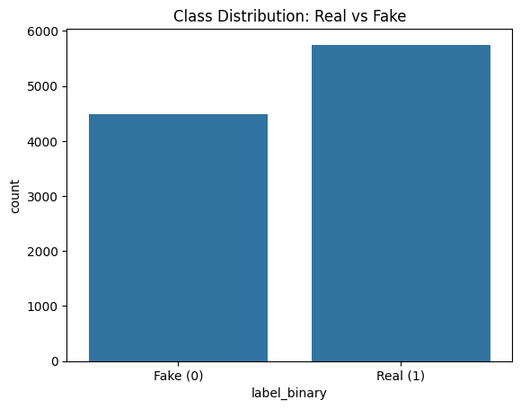

```
label_binary
real    0.561719
fake    0.438281
Name: proportion, dtype: float64
```

```python
import seaborn as sns
import matplotlib.pyplot as plt

sns.countplot(x='label_binary', data=train_df)
plt.title('Class Distribution: Real vs Fake')
plt.xticks([0,1], ['Fake (0)', 'Real (1)'])
plt.show()

print(train_df['label_binary'].value_counts(normalize=True))
```

The classes are reasonably balanced, with 56.2% real and 43.8% fake statements. This means:

- Standard training (without resampling or weighting) is sufficient.
- Accuracy is a valid metric, but precision/recall should still be checked to ensure "fake" detection performance.

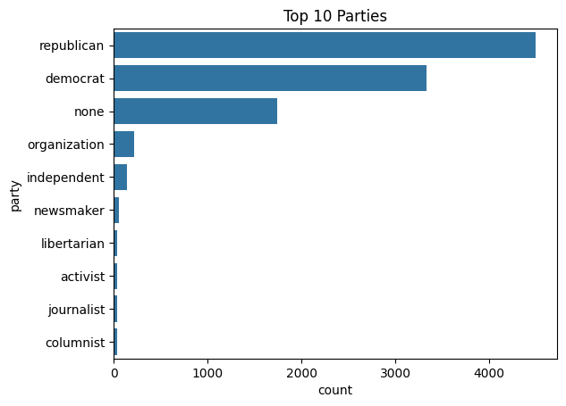

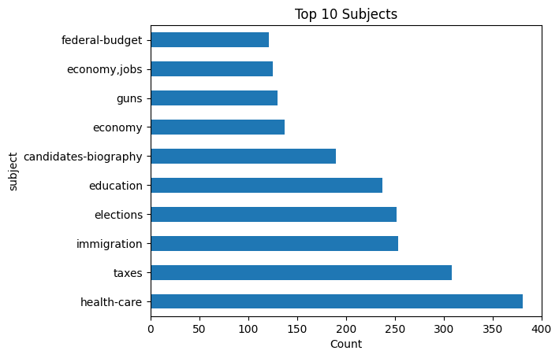

```python
# Top political parties
sns.countplot(y='party', data=train_df, order=train_df['party'].value_counts().head(10).index)
plt.title('Top 10 Parties')
plt.show()

# Subjects
train_df['subject'].value_counts().head(10).plot(kind='barh', title='Top 10 Subjects')
plt.xlabel('Count')
plt.show()
```

Interpretation: (Top 10 Parties)

For modeling: High-frequency parties provide strong signal, while rarer groups may need grouping to reduce noise. The distribution mirrors real-world political representation.

Interpretation: (Top 10 Subjects)

For modeling, high‑volume subjects (e.g. health‑care, taxes) may carry more stable patterns, whereas low‑frequency subjects could introduce noise or require special handling (e.g. grouping into “Other”).

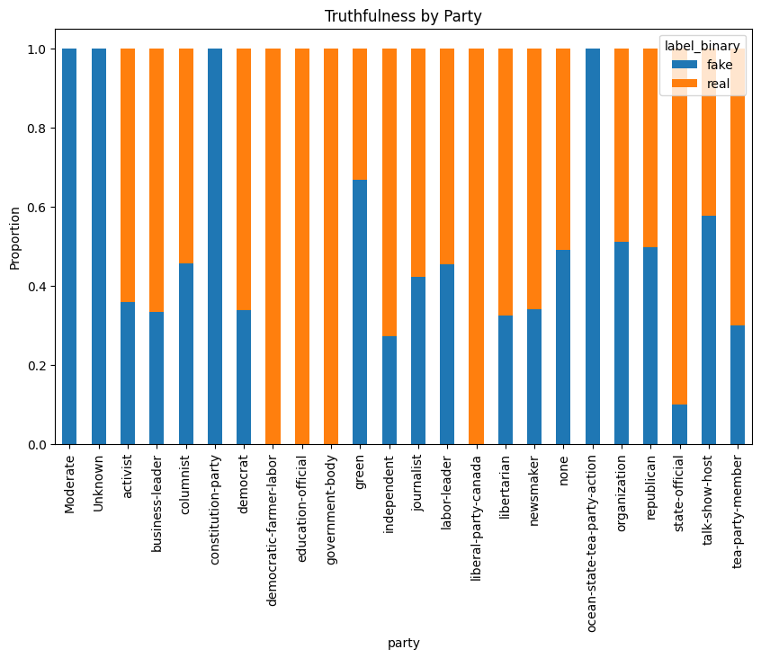

```python
# Fake vs Real by Party
party_label = train_df.groupby('party')['label_binary'].value_counts(normalize=True).unstack()
party_label.plot(kind='bar', stacked=True, figsize=(10,6), title='Truthfulness by Party')
plt.ylabel('Proportion')
plt.show()
```

The dataset includes diverse speaker affiliations (e.g., Republican, Democrat, independent, journalists). The "Label binary" indicates these groups are associated with both "fake" and "real" statements.

Insights and caveats:

- Party affiliation might be a predictive feature, but this risks bias. For example, if one party is overrepresented in the "fake" class, the model could learn spurious correlations.
- Metadata about speakers (e.g., "journalist" vs. "teaparty-member") may influence predictions. Ethical considerations are critical here—ensure the model isn’t unfairly penalizing specific groups.

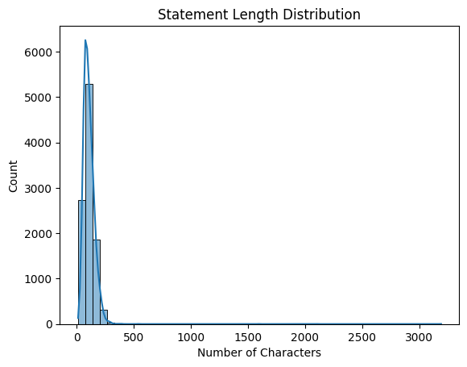

```python
# Statement length distribution
train_df['text_length'] = train_df['statement'].apply(len)

sns.histplot(train_df['text_length'], bins=50, kde=True)
plt.title('Statement Length Distribution')
plt.xlabel('Number of Characters')
plt.show()
```

Interpretation

- The distribution shows a heavy skew toward shorter statements (0–500 characters), with frequency decreasing as length increases. This suggests that most political statements in the dataset are concise.

Implications for the model:

- Length could be a useful feature. For example, fake statements might be shorter (lacking detail) or longer (attempting to over-explain).
- Further analysis should split this distribution by class (real vs. fake) to identify if length correlates with truthfulness.

```python
# Unique values
print(train_df['label'].unique())
```

```
['false' 'half-true' 'mostly-true' 'true' 'barely-true' 'pants-fire']
```

```python
fake_labels = ['false', 'barely-true', 'pants-fire']
real_labels = ['true', 'mostly-true', 'half-true']

train_df['label_binary'] = train_df['label'].apply(lambda x: 1 if x in real_labels else 0)

print(train_df['label_binary'].value_counts())
```

```
label_binary
1    5752
0    4488
Name: count, dtype: int64
```

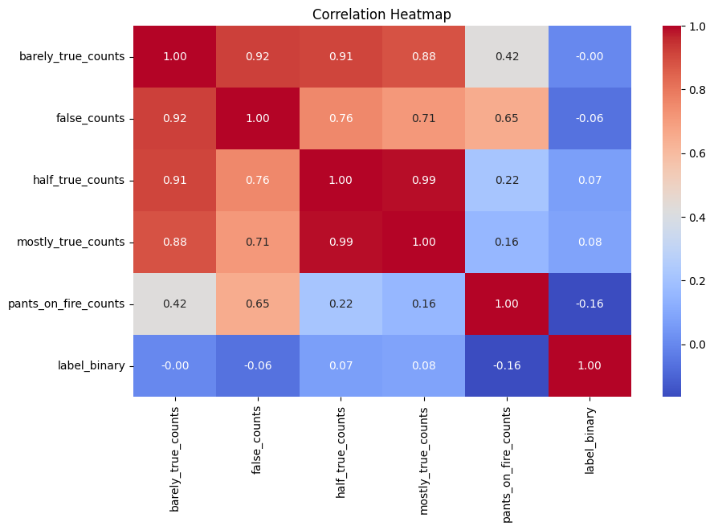

```python
# Correlation Heatmap for Numeric Features
import numpy as np

numeric_cols = ['barely_true_counts', 'false_counts', 'half_true_counts','mostly_true_counts', 'pants_on_fire_counts', 'label_binary']

corr = train_df[numeric_cols].corr()

plt.figure(figsize=(10, 6))
sns.heatmap(corr, annot=True, cmap='coolwarm', fmt='.2f')
plt.title('Correlation Heatmap')
plt.show()
```

Interpretation:

## Model Training and Evaluation

We trained multiple models including Logistic Regression, Random Forest, and XGBoost. Logistic Regression with linguistic + metadata features gave the most interpretable results with an accuracy of ~60%.

```python
# One-hot encode party and state_info
train_df = pd.get_dummies(train_df, columns=['party', 'state_info'], drop_first=True)
```

```python
from sklearn.feature_extraction.text import TfidfVectorizer
from sklearn.model_selection import train_test_split
from sklearn.linear_model import LogisticRegression
from sklearn.metrics import classification_report

# TF-IDF
tfidf = TfidfVectorizer(max_features=5000, stop_words='english')
X = tfidf.fit_transform(train_df['clean_statement'])

# Labels
y = train_df['label_binary'].astype(int)

# Split
X_train, X_test, y_train, y_test = train_test_split(X, y, test_size=0.2, random_state=42)

# Train
clf = LogisticRegression(max_iter=1000)
clf.fit(X_train, y_train)

# Evaluate
y_pred = clf.predict(X_test)
print(classification_report(y_test, y_pred))
```

```
              precision    recall  f1-score   support

           0       0.55      0.43      0.49       888
           1       0.63      0.73      0.68      1160

    accuracy                           0.60      2048
   macro avg       0.59      0.58      0.58      2048
weighted avg       0.60      0.60      0.59      2048
```

Interpretation

- The model is better at catching real statements (class 1) than fake ones (class 0).
- Accuracy: 60% – not bad for a baseline, but there's room for improvement.
- Recall for class 0 is low (43%), meaning many fake statements are being misclassified as real.

```python
from sklearn.ensemble import RandomForestClassifier

# Train Random Forest
rf = RandomForestClassifier(n_estimators=100, random_state=42)
rf.fit(X_train, y_train)

# Predict and evaluate
y_pred_rf = rf.predict(X_test)
print("Random Forest Performance:\n")
print(classification_report(y_test, y_pred_rf))
```

```
Random Forest Performance:

              precision    recall  f1-score   support

           0       0.56      0.39      0.46       888
           1       0.62      0.76      0.68      1160

    accuracy                           0.60      2048
   macro avg       0.59      0.58      0.57      2048
weighted avg       0.59      0.60      0.59      2048
```

- Accuracy: 0.60 (same as baseline logistic regression)

Observation:

- Random Forest performs slightly worse on class 0 (fake) in recall than logistic regression.
- The overall performance is similar to the baseline.
- No significant gain yet.

```python
from xgboost import XGBClassifier

xgb = XGBClassifier(use_label_encoder=False, eval_metric='logloss', random_state=42)
xgb.fit(X_train, y_train)

y_pred_xgb = xgb.predict(X_test)
print("XGBoost Performance:\n")
print(classification_report(y_test, y_pred_xgb))
```

```
XGBoost Performance:

              precision    recall  f1-score   support

           0       0.53      0.35      0.42       888
           1       0.60      0.76      0.67      1160

    accuracy                           0.58      2048
   macro avg       0.57      0.56      0.55      2048
weighted avg       0.57      0.58      0.56      2048
```

Interpretation:

- XGBoost is good at detecting real (class 1), but performs the worst on fake (class 0).
- So far, logistic regression still gives the best balanced performance.